# Plotting

The function `ggplot_dt` takes a data table containing two columns named `lon` and `lat` that should specify a regular longitude-latitude grid, as well as some data to use for coloring the map. The naming of the columns is important in that the function will not work if you, for example, name the longitude column `long` or `Lon`. An easy example is the following

```r
data("chirps_monthly")

dt = copy(chirps_monthly) # to manipulate the data table: chirps_monthly has locked binding

dt2020 = dt[year == 2020 & month == 10] # reduce the observed precipitation data to a single time slice, namely October 2020
print(dt2020)
```

```
##        lon   lat        prec month year terc_cat
##    1: 22.0 -12.0 2.981750252    10 2020        0
##    2: 22.0 -11.5 3.382063644    10 2020        0
##    3: 22.0 -11.0 3.250394658    10 2020        0
##    4: 22.0 -10.5 3.065396443    10 2020       -1
##    5: 22.0 -10.0 3.416906726    10 2020       -1
##   ---
## 3480: 51.5  21.0 0.033333333    10 2020       -1
## 3481: 51.5  21.5 0.033333333    10 2020        0
## 3482: 51.5  22.0 0.032608688    10 2020       -1
## 3483: 51.5  22.5 0.001594238    10 2020       -1
## 3484: 51.5  23.0 0.000000000    10 2020       -1
```

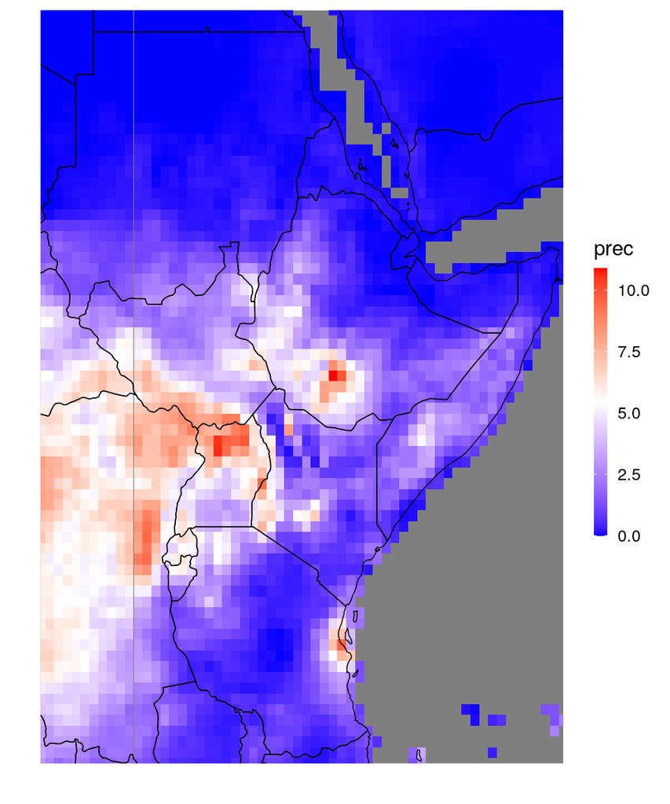

```r
ggplot_dt(dt2020,'prec')
```

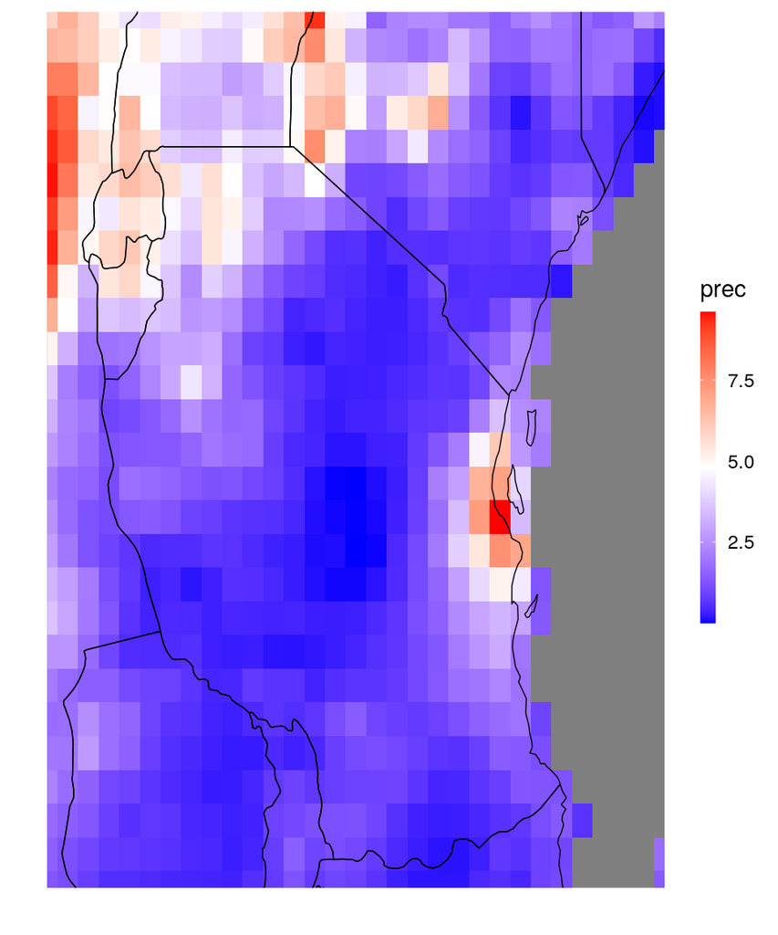

```r
dt_sub  = dt2020[lon %between% c(28,43) & lat %between% c(-12,1)] # a region containing Tanzania
ggplot_dt(dt_sub)
```

The function has further optional arguments (also recall that you can access the function documentation summarizing all of this by typing `?ggplot_dt`):

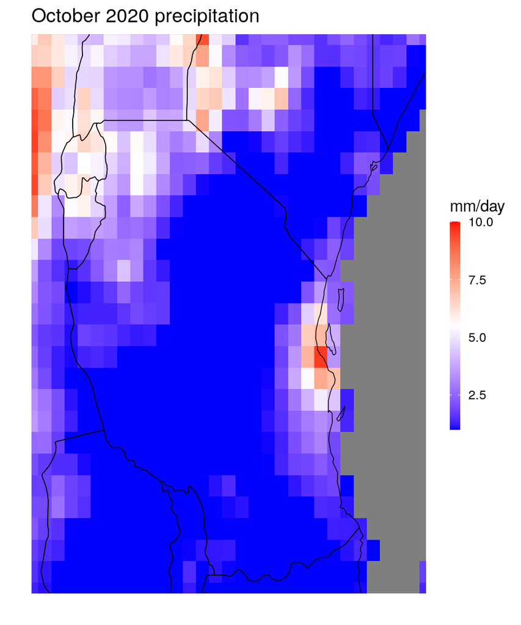

```r
ggplot_dt(dt_sub,'prec',
          mn = 'October 2020 precipitation', # add a title to the plot
          rr = c(1,10), # fix the limits of the color scale
          name = 'mm/day') # change the legend label
```

In this example we set the lower limit of the color scale to 1 and the upper limit to 10. Note that the plot truncates the data at the ends of the color scale, so every pixel with precipitation of below 1mm/day is now shown in the same blue color. Setting the range of the color scale is particularly useful to force symmetry around 0, e.g. when plotting correlations or anomalies:

```r
dt[,clim := mean(prec), by = .(lon,lat,month)] # add a climatology column
dt[,ano := prec - clim] # add anomaly as another column
print(dt)
```

```
##          lon   lat      prec month year terc_cat      clim          ano
##      1: 22.0 -12.0 1.9301587    10 1981       -1 2.8169255 -0.886766778
##      2: 22.0 -11.5 2.1351602    10 1981       -1 3.0905585 -0.955398264
##      3: 22.0 -11.0 2.7692883    10 1981       -1 3.4675703 -0.698281996
##      4: 22.0 -10.5 3.9201619    10 1981        0 3.8808617  0.039300191
##      5: 22.0 -10.0 4.8720656    10 1981        1 4.2989969  0.573068714
##     ---
## 418076: 51.5  21.0 0.2404348    12 2020       -1 0.2559819 -0.015547112
## 418077: 51.5  21.5 0.2184058    12 2020       -1 0.2415870 -0.023181188
## 418078: 51.5  22.0 0.2053623    12 2020       -1 0.2151377 -0.009775418
## 418079: 51.5  22.5 0.1615942    12 2020       -1 0.1870797 -0.025485473
## 418080: 51.5  23.0 0.1387682    12 2020       -1 0.1701314 -0.031363167
```

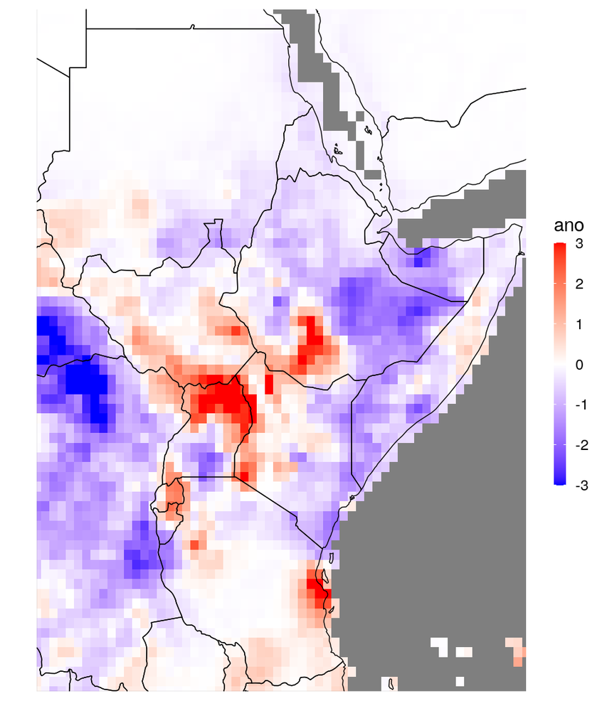

```r
ggplot_dt(dt[month == 10 & year == 2020], 'ano', rr = c(-3,3))
```

Now, in this plot positive rainfall anomalies are shown red while negative anomalies are blue, which is very counterintuitive. The function allows us to specify the three used colors by name with the arguments `low`,`mid`, and `high`. So here's an anomaly plot looking a bit nicer:

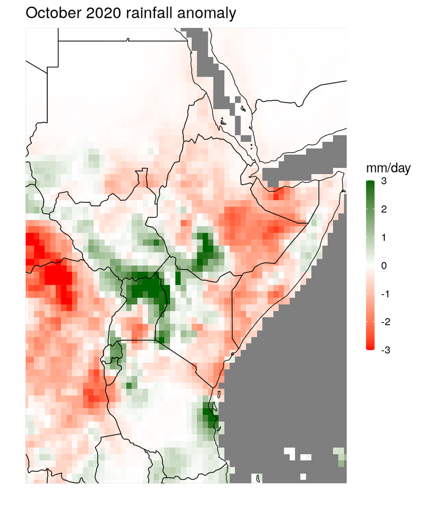

```r
ggplot_dt(dt[month == 10 & year == 2020], 'ano',
          mn = 'October 2020 rainfall anomaly',
          rr = c(-3,3),
          low = 'red', mid = 'white', high = 'darkgreen',
          name = 'mm/day')
```

Note that we set the range argument to `c(-3,3)`. Fixing the range makes mostly sense when the range is known (e.g. for correlation plots), or when you want to compare several plots (e.g. for comparing mean square error of different NWP models, all plots should have the same range). If we leave the range argument `rr` free, the range is determined from the data. However, when we do this for our anomaly plot this has an undesired sideeffect:

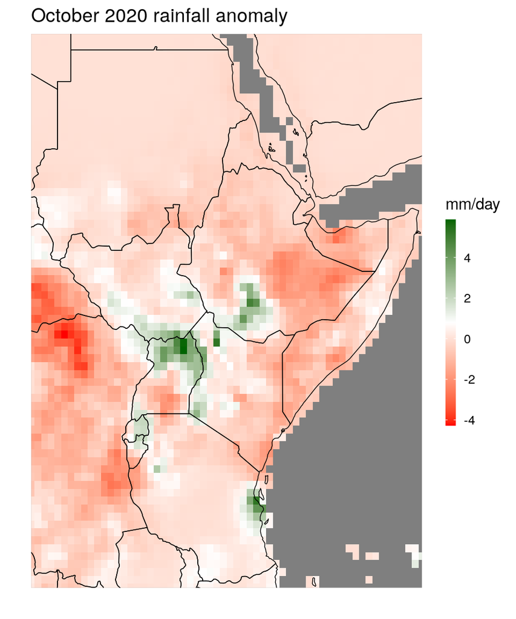

```r
ggplot_dt(dt[month == 10 & year == 2020], 'ano',
          mn = 'October 2020 rainfall anomaly',
          low = 'red', mid = 'white', high = 'darkgreen',
          name = 'mm/day')
```

The color scale is no longer centered (white) at 0, but in the center of the (now asymetric) range. As a consequence, all gridpoints with anomaly 0 are shown in a light red. To fix this we can use the `midpoint` argument:

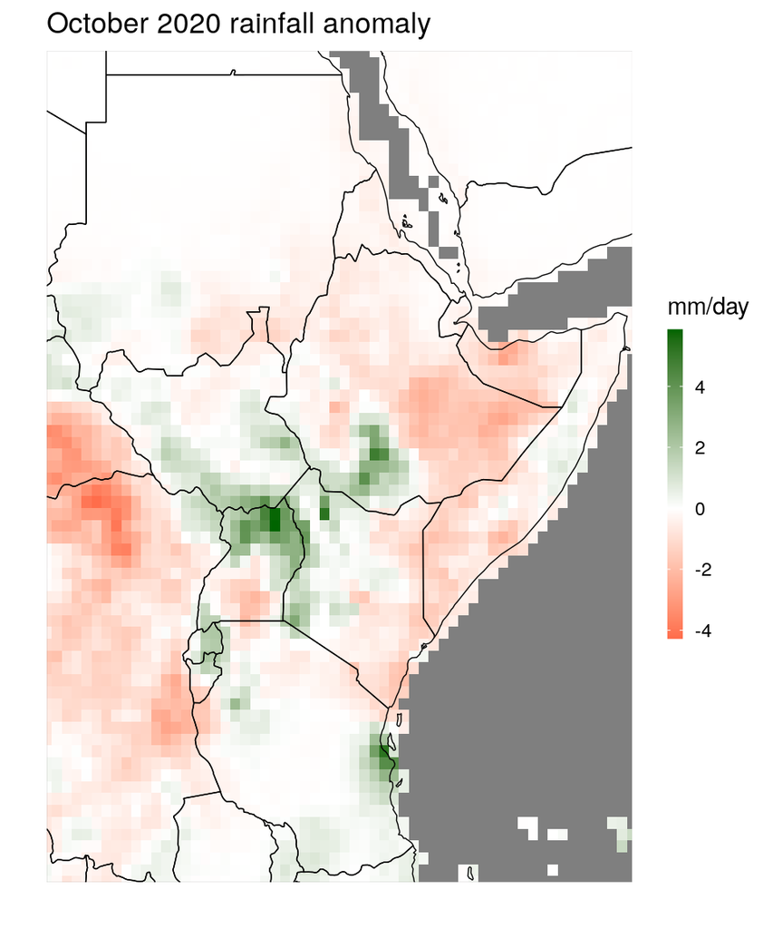

```r
ggplot_dt(dt[month == 10 & year == 2020], 'ano',
          mn = 'October 2020 rainfall anomaly',
          low = 'red', mid = 'white', high = 'darkgreen',
          midpoint = 0,
          name = 'mm/day')
```

Another, maybe surprising, use for the `midpoint` argument is that we can generate plots with a colorscale with only two colors. For example, going back to plotting the observed rainfall we can do the following:

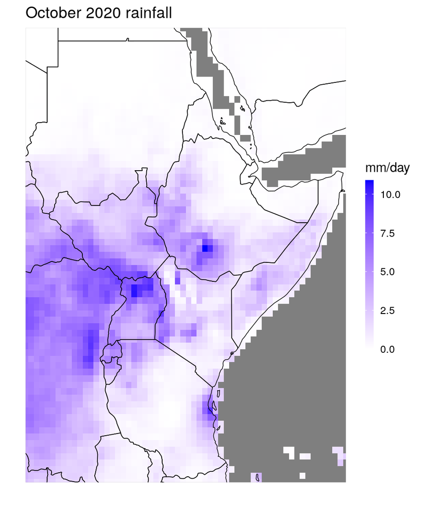

```r
ggplot_dt(dt[month == 10 & year == 2020], 'prec',
          mn = 'October 2020 rainfall',
          mid = 'white', high = 'blue',
          midpoint = 0,
          name = 'mm/day')
```

Here, we set the midpoint to 0, which is the minimum of our data (since observed rainfall is never below 0). Consequently, the second half of the colorscale extending below 0 is ignored.

Finally, the function allows to discretize the color scale. To this end we need to set the argument `discrete_cs` to `TRUE`. We can then control the breaks of the discrete colorscale by one of the arguments `binwidth`, `n.breaks`, or `breaks` (the latter takes a vector containing all breakpoints). The argument `n.breaks` (which is passed to the function `ggplot2::scale_fill_steps2`) tries to find 'nice' breaks and does not work reliably. To revisit the anomaly plot from above:

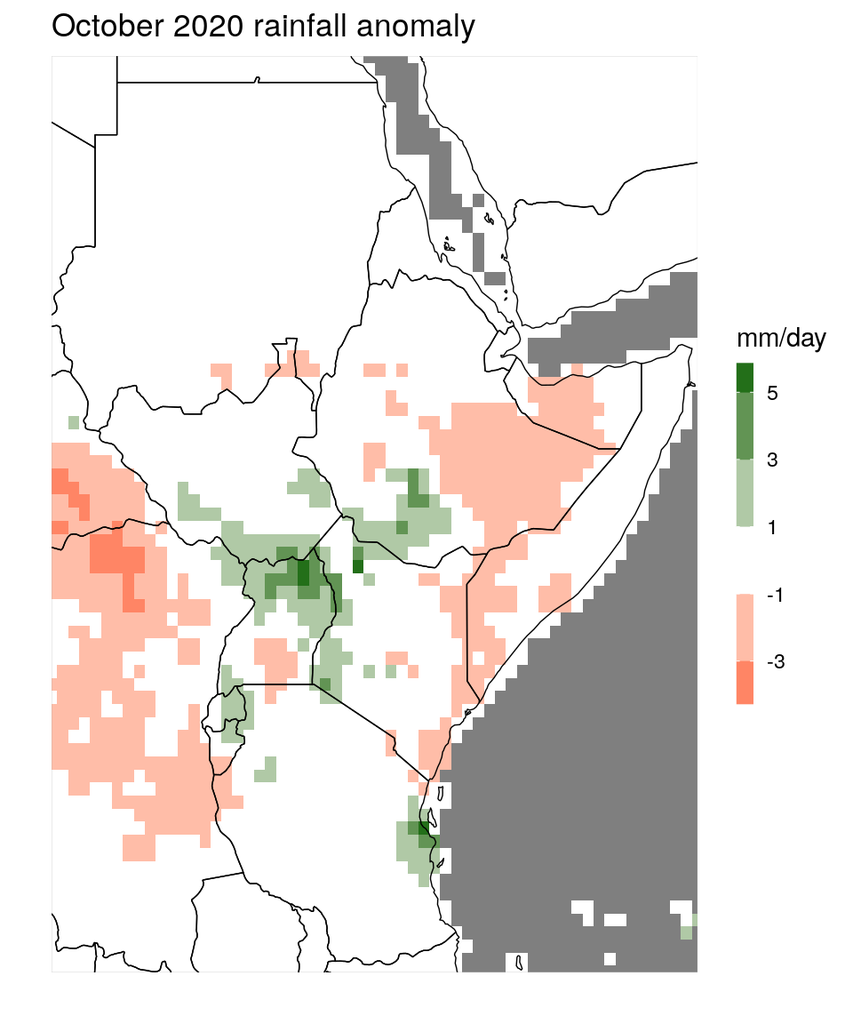

```r
ggplot_dt(dt[month == 10 & year == 2020], 'ano',
          mn = 'October 2020 rainfall anomaly',
          discrete_cs = TRUE, binwidth = 2,
          low = 'red', mid = 'white', high = 'darkgreen',
          midpoint = 0,
          name = 'mm/day')
```

For saving a created plot the syntax is as follows:

```r
pdf(file = '<path to file and filename>.pdf', width = ...,height = ...)
  print(pp)
dev.off()
```

This creates a .pdf file, but you can print .png and some other file formats similarly, see `?Devices` for an overview.

One final remark: Often you will deal with data tables that contain spatio-temporal data. It is then important to remember subselecting the particular timeslice you want to view, (October 2020 in the examples above). The function `ggplot_dt` by default tries to select the first timeslice of tempo-spatial data. This is convenient for a quick first look at your data. Here an example:

```r
print(chirps_monthly) # a data table with multiple months and years and locations, so spatio-temporal data
```

```
##          lon   lat      prec month year terc_cat
##      1: 22.0 -12.0 1.9301587    10 1981       -1
##      2: 22.0 -11.5 2.1351602    10 1981       -1
##      3: 22.0 -11.0 2.7692883    10 1981       -1
##      4: 22.0 -10.5 3.9201619    10 1981        0
##      5: 22.0 -10.0 4.8720656    10 1981        1
##     ---
## 418076: 51.5  21.0 0.2404348    12 2020       -1
## 418077: 51.5  21.5 0.2184058    12 2020       -1
## 418078: 51.5  22.0 0.2053623    12 2020       -1
## 418079: 51.5  22.5 0.1615942    12 2020       -1
## 418080: 51.5  23.0 0.1387682    12 2020       -1
```

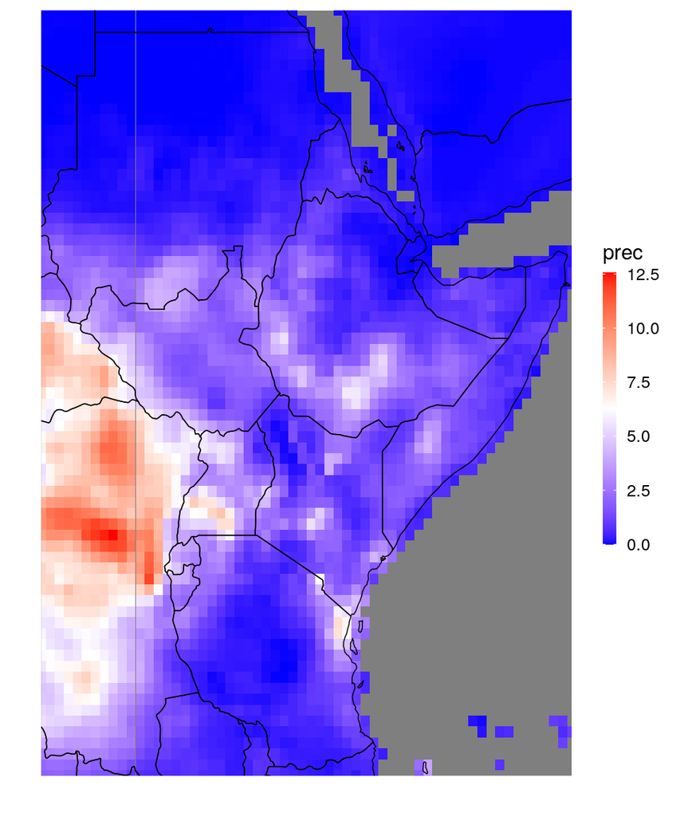

```r
ggplot_dt(chirps_monthly) # generates a plot of the precipitation of October 1981 (first timeslice), for a first quick impression of your data.
```

## Plotting values for selected countries

Above, we have already seen an option how to restrict a plot to a particular country: by manually subsetting the data to a rectangle of longitudes and latitudes containing that specific country. This is of course quite tedious, and to make our lives easier we can use the `restrict_to_country`-function that takes a data table and a country name, and subsets the data table to only contain gridpoints in the specified country. Currently, the function accepts the following country names: Burundi, Eritrea, Ethiopia, Kenya, Rwanda, Somalia, South Sudan, Sudan, Tansania, Uganda.

```r
dt_new = restrict_to_country(dt[month == 10 & year == 2020],'Kenya')
print(dt_new)
```

```
##       lon  lat      prec month year terc_cat     clim        ano
##   1: 34.0 -1.0 4.9593979    10 2020        1 2.964475  1.9949232
##   2: 34.0 -0.5 4.7645891    10 2020        1 3.639693  1.1248956
##   3: 34.0  0.0 4.6154697    10 2020        1 4.284345  0.3311242
##   4: 34.5 -1.0 7.5550100    10 2020        1 4.380272  3.1747380
##   5: 34.5 -0.5 6.4341863    10 2020        1 4.056996  2.3771907
##  ---
## 187: 41.0 -1.0 0.7533339    10 2020       -1 2.456691 -1.7033568
## 188: 41.0  3.0 1.1354665    10 2020        0 2.135546 -1.0000791
## 189: 41.0  3.5 1.5012010    10 2020        0 2.191273 -0.6900723
## 190: 41.0  4.0 1.8609376    10 2020        0 2.431412 -0.5704748
## 191: 41.5  3.5 1.3543324    10 2020        0 2.447758 -1.0934261
```

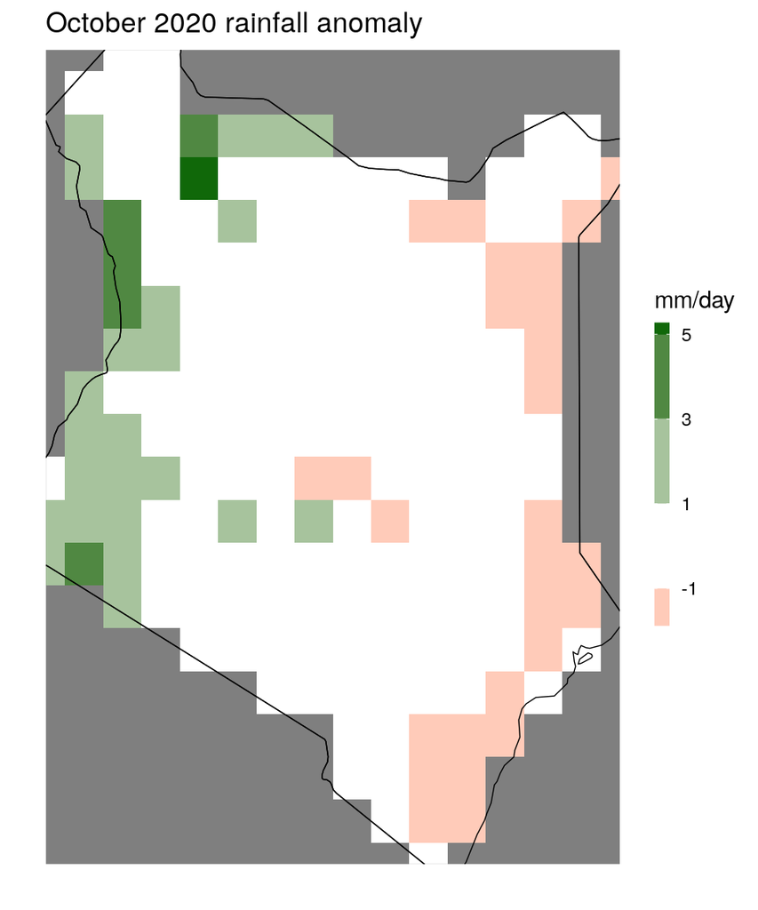

```r
ggplot_dt(dt_new, 'ano',
          mn = 'October 2020 rainfall anomaly',
          discrete_cs = TRUE, binwidth = 2,
          low = 'red', mid = 'white', high = 'darkgreen',
          midpoint = 0,
          name = 'mm/day')
```

As we can see, the function restricts the data to all gridcells for which the centerpoint lies within the specified country. This is useful, for example, for calculating mean scores for the specified country. However, it is not optimal for plotting since every grid cell past the border is censored even though the original data table contained values there. To this end, the `restrict_to_country` function has a `rectangle`-argument that you can set to `TRUE` for plotting:

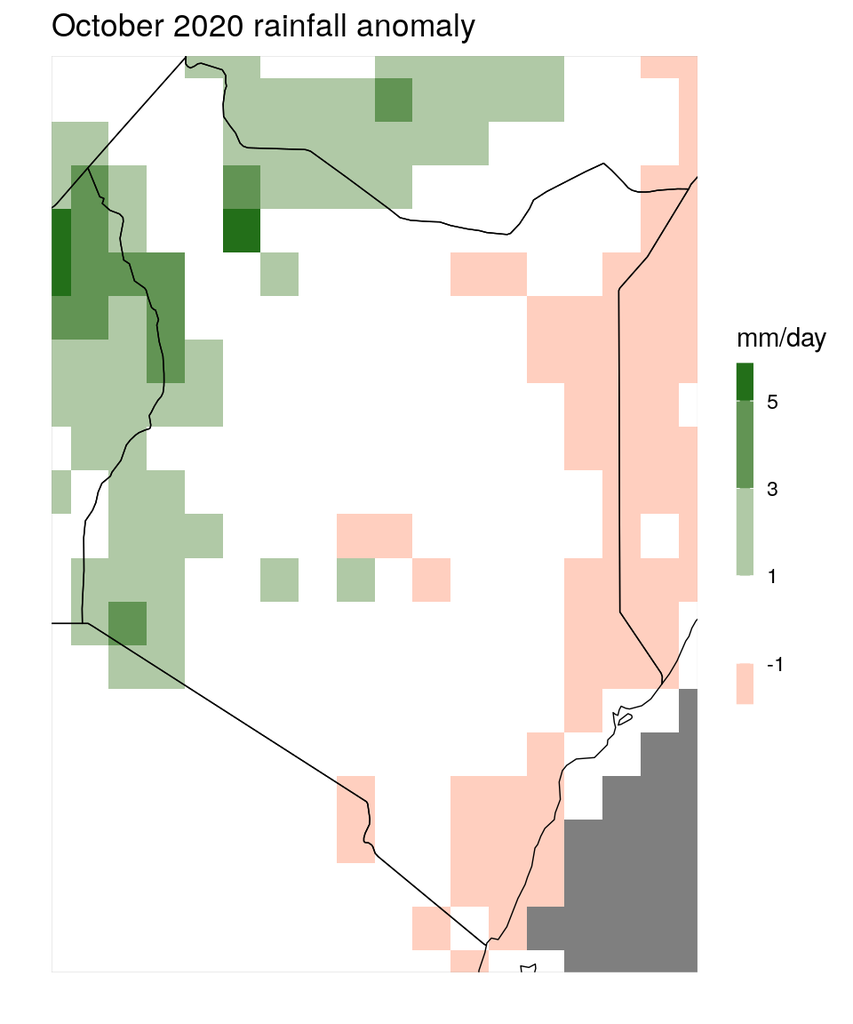

```r
dt_new = restrict_to_country(dt[month == 10 & year == 2020],'Kenya', rectangle = TRUE)
ggplot_dt(dt_new, 'ano',
          mn = 'October 2020 rainfall anomaly',
          discrete_cs = TRUE, binwidth = 2,
          low = 'red', mid = 'white', high = 'darkgreen',
          midpoint = 0,
          name = 'mm/day')
```

Instead of a single country name you can also pass multiple country names in a vector to the function. Moreover, when you use `rectangle = TRUE`, you can specify a tolerance `tol` in order to widen the plotting window:

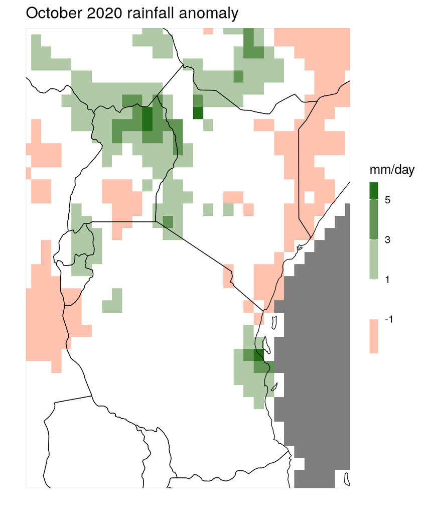

```r
dt_new = restrict_to_country(dt[month == 10 & year == 2020],
                             c('Kenya','Tanzania'),
                             rectangle = TRUE,tol = 2)
ggplot_dt(dt_new, 'ano',
          mn = 'October 2020 rainfall anomaly',
          discrete_cs = TRUE, binwidth = 2,
          low = 'red', mid = 'white', high = 'darkgreen',
          midpoint = 0,
          name = 'mm/day')
```

The `tol = 2` argument means that the function will include a buffer zone of 2 degrees lon/lat outside the specified countries (i.e. 4 gridpoints to each side). Note that the buffer to the south of Tanzania is smaller, because the original data table `dt` does not contain any data further south.

## Customized plots

The function `ggplot_dt` is, as its name suggests, based on the package `ggplot2`, see https://ggplot2-book.org/. In `ggplot2`, plots are composed out of multiple layers, allowing for successive adding of layers. This can help us to generate highly customized plots. As an example, let's revisit the anomaly plot from above and add the location of Nairobi an Addis Abbaba to it:

```r
library(ggplot2)

# get locations as data table:
loc = data.table(name = c('Addis Abbaba','Nairobi'),lon = c(38.77,36.84),lat = c(9,-1.28))
print(loc)
```

```
##            name   lon   lat
## 1: Addis Abbaba 38.77  9.00
## 2:      Nairobi 36.84 -1.28
```

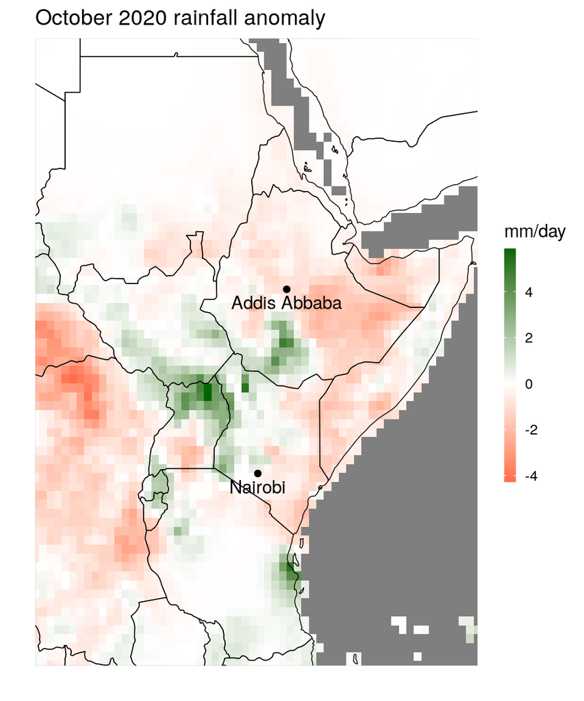

```r
pp = ggplot_dt(dt[month == 10 & year == 2020], 'ano',
               mn = 'October 2020 rainfall anomaly',
               low = 'red', mid = 'white', high = 'darkgreen',
               midpoint = 0,
               name = 'mm/day') +
     geom_point(data = loc,mapping = aes(x = lon,y = lat)) +
     geom_text(data = loc,mapping = aes(x = lon,y = lat,label = name),vjust = 1.5)

print(pp)
```

Here, we added two layers to the original plot, the first one being the `geom_point`-layer that creates the two points at the locations of the cities, and the second being the `geom_text`-layer that labels the points by the city names. `ggplot2` is a widely used package and there is a large variety of tutorials and books out there that can help you getting familiar with the syntax.

A frequently required operation is the changing of the font sizes of title and labels. The easiest way to do this is the command

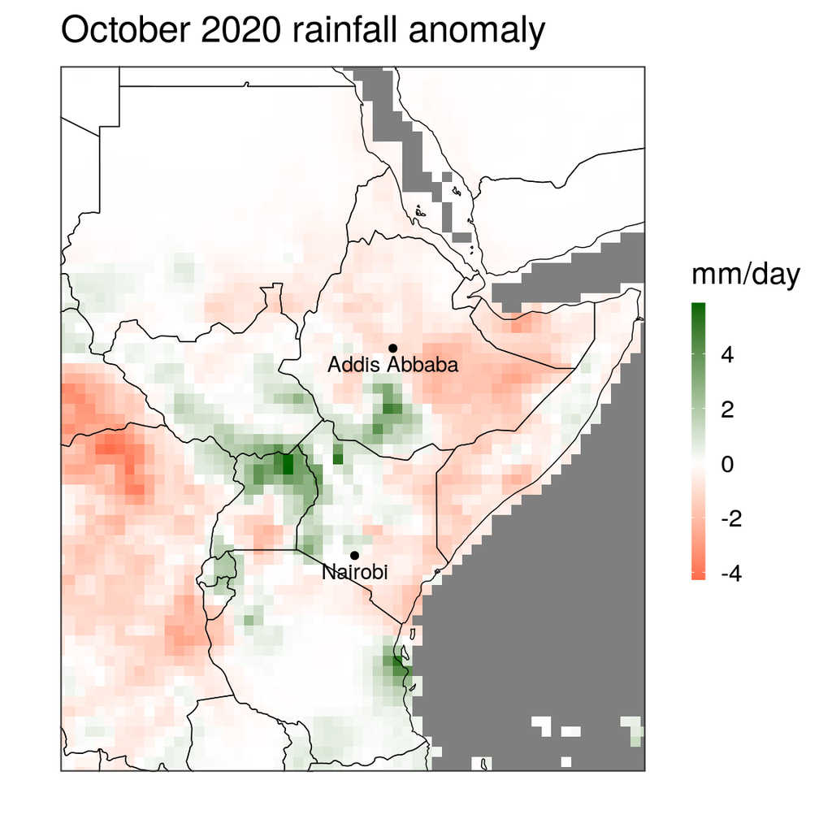

```r
theme_set(theme_bw(base_size = 16)) # defaults to 12
print(pp)
```

We can also use ggplots adding-layer-syntax to overwrite existing layers, for example if we want a fully customized colorscale:

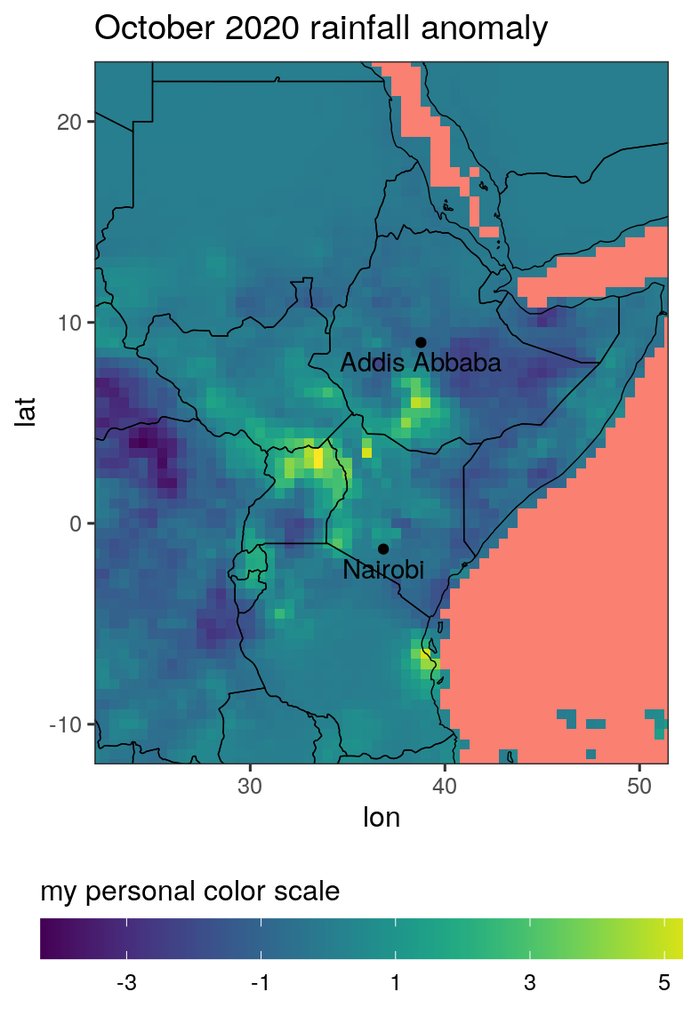

```r
library(viridis) # the viridis package contains some nice color scales
pp_new = pp + scale_fill_viridis(name = 'my_color_scale',
                                 breaks = seq(-5,5,by = 2),
                                 guide = guide_colorbar(title = 'my personal color scale',
                                                        title.position = 'top',
                                                        barwidth = 20,
                                                        direction = 'horizontal')) +
              xlab('lon') + ylab('lat') +   # label axis
              theme(panel.background = element_rect(fill = 'salmon'), # change background color (used for missing values) to something whackey
                    axis.ticks = element_line(), # add ticks...
                    axis.text = element_text(),  # ... and labels for the axis, i.e. some lons and lats.
                    legend.position = 'bottom')

print(pp_new)
```

For comparing multiple plots (potentially all of them with the same legend), the function `ggpubr::ggarrange` is useful:

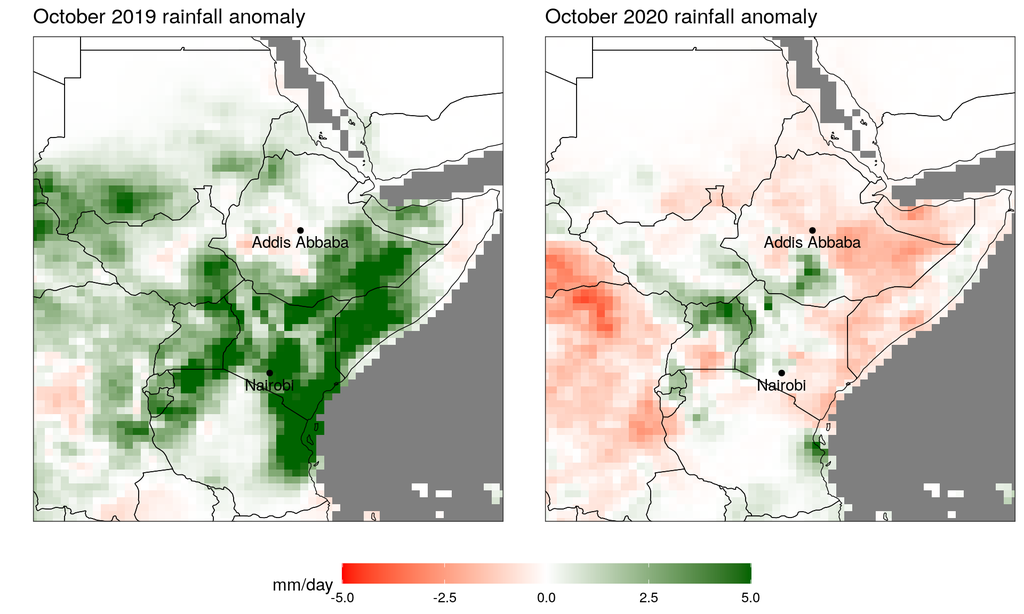

```r
library(ggpubr)
# compare 2019 October anomaly to 2020 anomaly:
rr = c(-5,5) # force color scale to be identical for the plots

pp1 = ggplot_dt(dt[month == 10 & year == 2019], 'ano',
                rr = rr,
                mn = 'October 2019 rainfall anomaly',
                low = 'red', mid = 'white', high = 'darkgreen',
                guide = guide_colorbar(barwidth = 20,barheight = 1,direction = 'horizontal'),
                midpoint = 0,
                name = 'mm/day') +
  geom_point(data = loc,mapping = aes(x = lon,y = lat)) +
  geom_text(data = loc,mapping = aes(x = lon,y = lat,label = name),vjust = 1.5)

pp2 = ggplot_dt(dt[month == 10 & year == 2020], 'ano',
                rr = rr,
                mn = 'October 2020 rainfall anomaly',
                low = 'red', mid = 'white', high = 'darkgreen',
                midpoint = 0,
                name = 'mm/day') +
  geom_point(data = loc,mapping = aes(x = lon,y = lat)) +
  geom_text(data = loc,mapping = aes(x = lon,y = lat,label = name),vjust = 1.5)


ggarrange(pp1,pp2,ncol = 2,common.legend = TRUE,legend = 'bottom')
```